# Bilgi Yönetim Sistemleri - Bitirme Projesi Rapor : Süleyman Oruç 190401026

**Gerekli kütüphanelerin yüklenmesi**

```r
library(readr)
library(dplyr)
library(tidyr)
library(rpart)
library(rpart.plot)
library(caret)
library(ggplot2)
```

**Random veri oluşturulması**

```r
veri1 <-  read.csv("veri2.csv")
veri2 <-  read.csv("veri3.csv")
phone <- read.csv("phone.csv")
info <- read.csv("info.csv")



Clientnum <- veri2[sample(nrow(veri2), 5000), c("CLIENTNUM")]
info_sample <- info[sample(nrow(info), 5000), c("first_name", "last_name", "email")]
phone <- phone[sample(nrow(phone), 5000), "Phone"]
BirthDay <- veri1[sample(nrow(veri1), 5000), c("CustomerDOB")]
TransactionDate <- veri1[sample(nrow(veri1), 5000), c("TransactionDate")]
age <- veri2[sample(nrow(veri2), 5000), c("Customer_Age", "Marital_Status")]
veri2_sample <- veri2[sample(nrow(veri2), 5000), c("Dependent_count","Card_Category","Income_Category", "Credit_Limit")]

# Birleştir
birlestirilmis_veri <- cbind(Clientnum, info_sample, phone, BirthDay, age, TransactionDate, veri2_sample)

#Eksik değerleri NA olarak güncelle
birlestirilmis_veri <- birlestirilmis_veri %>%
  mutate(Marital_Status = ifelse(Marital_Status == "Unknown", NA, Marital_Status))

birlestirilmis_veri <- birlestirilmis_veri %>%
  mutate(Income_Category = ifelse(Income_Category == "Unknown", NA, Income_Category))

birlestirilmis_veri <- birlestirilmis_veri %>%
  mutate(BirthDay = ifelse(BirthDay == "nan", NA, BirthDay))

# NA değerlerinin bulunduğu satırları silme
tamveri <- birlestirilmis_veri %>%
  filter(!is.na(Income_Category))

#Income_Category sütunununda ki verilerin character tipinden numeric tipine dönüştürülmesi sırasında hata alındığından bu şekilde denenmiştir.
#Hatanın neden çözüldüğü bilinmemektedir.
tamveri <- head(tamveri, 5000)

#Income_Category sütunununda ki verilerin character tipinden numeric tipine dönüştürülmesi

set.seed(123) # Rastgeleliği tekrarlanabilir kılmak için

tamveri <- tamveri %>%
  mutate(Income_Category = case_when(
    Income_Category == "Less than $40K" ~ sample(10000:40000, 1),
    Income_Category == "$40K - $60K" ~ sample(40000:60000, 1),
    Income_Category == "$60K - $80K" ~ sample(60000:80000, 1),
    Income_Category == "$80K - $120K" ~ sample(80000:120000, 1),
    Income_Category == "$120K +" ~ sample(120000:200000, 1),
    TRUE ~ as.numeric(Income_Category)  # Diğer durumlar için mevcut değeri korur
  ))

#Income_Category sütununun
mean_income <- mean(tamveri$Income_Category)

#Veri setinde Income_Category sütununda bulunan Nan değerlerin o sütunun ortalama değeri ile doldurulması
birlestirilmis_veri <- birlestirilmis_veri %>%
  mutate(Income_Category = ifelse(is.na(Income_Category), mean_income, Income_Category))

birlestirilmis_veri <- head(birlestirilmis_veri, 5000)

#Income_Category sütunununda ki verilerin character tipinden numeric tipine dönüştürülmesi
birlestirilmis_veri <- birlestirilmis_veri %>%
  mutate(Income_Category = case_when(
    Income_Category == "Less than $40K" ~ sample(10000:40000, 1),
    Income_Category == "$40K - $60K" ~ sample(40000:60000, 1),
    Income_Category == "$60K - $80K" ~ sample(60000:80000, 1),
    Income_Category == "$80K - $120K" ~ sample(80000:120000, 1),
    Income_Category == "$120K +" ~ sample(120000:200000, 1),
    TRUE ~ as.numeric(Income_Category)  # Diğer durumlar için mevcut değeri korur
  ))

# Marital_Status sütununda ki verilerin anlamlı hale getirilmesi

birlestirilmis_veri <- birlestirilmis_veri %>%
  mutate(Marital_Status = ifelse(Marital_Status == "Single", "Bekar", Marital_Status))

birlestirilmis_veri <- birlestirilmis_veri %>%
  mutate(Marital_Status = ifelse(Marital_Status == "Married", "Evli", Marital_Status))

birlestirilmis_veri <- birlestirilmis_veri %>%
  mutate(Marital_Status = ifelse(Marital_Status == "Divorced", "Bosanmis", Marital_Status))

#Card_Category sütununda ki verilerin anlamlı hale getirilmesi

birlestirilmis_veri <- birlestirilmis_veri %>%
  mutate(Card_Category = ifelse(Card_Category == "Blue", "Temel", Card_Category))

birlestirilmis_veri <- birlestirilmis_veri %>%
  mutate(Card_Category = ifelse(Card_Category == "Silver", "Orta", Card_Category))

birlestirilmis_veri <- birlestirilmis_veri %>%
  mutate(Card_Category = ifelse(Card_Category == "Gold", "İleri", Card_Category))

# Sütun adlarının değiştirilmesi
birlestirilmis_veri <- birlestirilmis_veri %>%
  rename(Gelir = Income_Category)

birlestirilmis_veri <- birlestirilmis_veri %>%
  rename(Musteri_Numarasi = Clientnum)

birlestirilmis_veri <- birlestirilmis_veri %>%
  rename(Isim = first_name)

birlestirilmis_veri <- birlestirilmis_veri %>%
  rename(Soyisim = last_name)

birlestirilmis_veri <- birlestirilmis_veri %>%
  rename(Telefon_numarasi = phone)

birlestirilmis_veri <- birlestirilmis_veri %>%
  rename(Dogum_gunu = BirthDay)

birlestirilmis_veri <- birlestirilmis_veri %>%
  rename(Yas = Customer_Age)

birlestirilmis_veri <- birlestirilmis_veri %>%
  rename(Medeni_durum = Marital_Status)

birlestirilmis_veri <- birlestirilmis_veri %>%
  rename(Islem_tarihi = TransactionDate)

birlestirilmis_veri <- birlestirilmis_veri %>%
  rename(Hesap_sayisi = Dependent_count)

birlestirilmis_veri <- birlestirilmis_veri %>%
  rename(Kart_kategori = Card_Category)

birlestirilmis_veri <- birlestirilmis_veri %>%
  rename(Kredi_limiti = Credit_Limit)
```

**Oluşturulan veri setine Kredi Onay sütununun eklenmesi**

```r
birlestirilmis_veri <- birlestirilmis_veri %>%
  mutate(Kredi_uygun = ifelse(Hesap_sayisi > 2 & Gelir > 63000 & Kredi_limiti > 8500, 1, 0))

birlestirilmis_veri <- birlestirilmis_veri %>%
  mutate(Kredi_uygun = ifelse(Hesap_sayisi <= 2 & Gelir > 63000 & Kredi_limiti > 8500, 1, Kredi_uygun))

birlestirilmis_veri <- birlestirilmis_veri %>%
  mutate(Kredi_uygun = ifelse(Hesap_sayisi > 2 & Gelir > 30000 & Kredi_limiti > 8500, 1, Kredi_uygun))

birlestirilmis_veri <- birlestirilmis_veri %>%
  mutate(Kredi_uygun = ifelse(Hesap_sayisi > 2 & Gelir > 63000 & Kredi_limiti > 5000, 1, Kredi_uygun))
```

**Makine öğrenmesi modelinin oluşturulması**

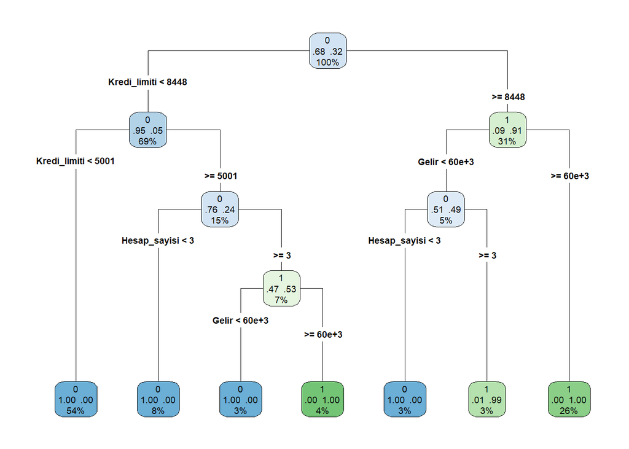

```r
set.seed(123)
train_index <- createDataPartition(birlestirilmis_veri$Kredi_uygun, p = 0.8, list = FALSE)
train_data <- birlestirilmis_veri[train_index, ]
test_data <- birlestirilmis_veri[-train_index, ]

# Karar ağacı modeli oluşturma
kredi_uygun_tree <- rpart(Kredi_uygun ~ Hesap_sayisi + Gelir + Kredi_limiti, data = train_data, method = "class")

# Modeli görselleştirme
rpart.plot(kredi_uygun_tree, type = 4, extra = 104)
```

```r
test_veri <-  read.csv("verib.csv")

# Test veri seti üzerinde tahmin yapma
test_pred <- predict(kredi_uygun_tree, test_veri, type = "class")



tahminler <- predict(kredi_uygun_tree, test_veri, type = "class")

# Tahminleri test veri setine ekleme
test_veri <- test_veri %>%
  mutate(Kredi_uygun = tahminler)
```

**Modelin performansının değerlendirilmesi**

```r
# Karışıklık Matrisi (Confusion Matrix) oluşturma
conf_matrix <- confusionMatrix(test_pred, factor(birlestirilmis_veri$Kredi_uygun))

# Performans metriklerini çıkarma
accuracy <- conf_matrix$overall["Accuracy"]
sensitivity <- conf_matrix$byClass["Sensitivity"]
specificity <- conf_matrix$byClass["Specificity"]
f1_score <- 2 * (sensitivity * specificity) / (sensitivity + specificity)

# Performans metriklerini bir data frame'e ekleme
performance_metrics <- data.frame(
  Metric = c("Accuracy", "Sensitivity", "Specificity", "F1 Score"),
  Value = c(accuracy, sensitivity, specificity, f1_score)
)

# Sonuçları gösterme
print(performance_metrics)
```

```
##        Metric     Value
## 1    Accuracy 0.5568000
## 2 Sensitivity 0.6711606
## 3 Specificity 0.3110831
## 4    F1 Score 0.4251221
```

**Analiz sonuçlarının görselleştirilmesi**

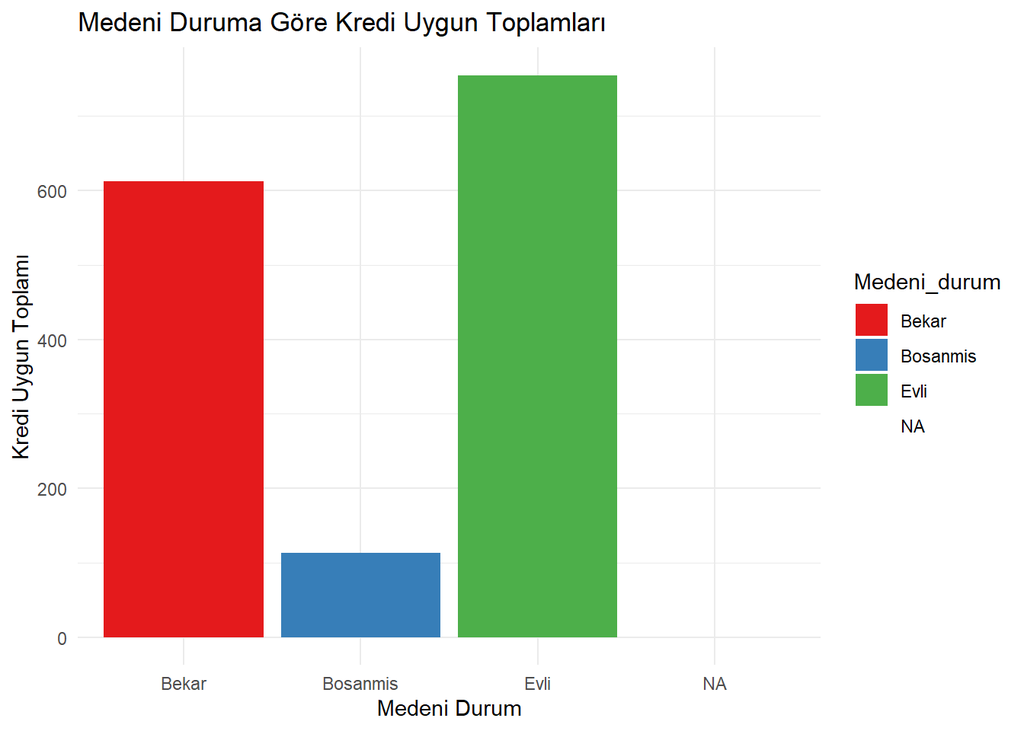

```r
# Medeni_durum'a göre gruplandırarak Kredi_uygun toplamını hesaplama
kredi_uygun_toplam <- birlestirilmis_veri %>%
  group_by(Medeni_durum) %>%
  summarise(Kredi_uygun_toplam = sum(Kredi_uygun))

# Grafiği oluşturma
ggplot(kredi_uygun_toplam, aes(x = Medeni_durum, y = Kredi_uygun_toplam, fill = Medeni_durum)) +
  geom_bar(stat = "identity") +
  labs(title = "Medeni Duruma Göre Kredi Uygun Toplamları",
       x = "Medeni Durum",
       y = "Kredi Uygun Toplamı") +
  theme_minimal() +
  scale_fill_brewer(palette = "Set1")
```

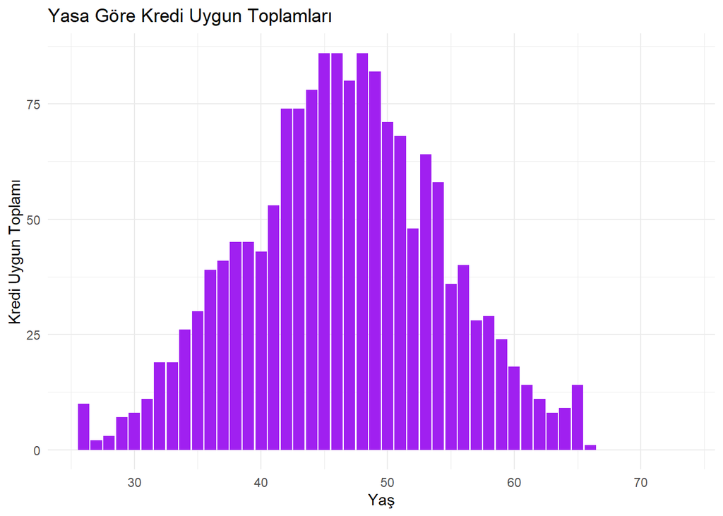

```r
kredi_uygun_toplam <- birlestirilmis_veri %>%
  group_by(Yas) %>%
  summarise(Kredi_uygun_toplam = sum(Kredi_uygun))

# Grafiği oluşturma
ggplot(kredi_uygun_toplam, aes(x = Yas, y = Kredi_uygun_toplam)) +
  geom_bar(stat = "identity", fill = "purple") +
  labs(title = "Yasa Göre Kredi Uygun Toplamları",
       x = "Yaş",
       y = "Kredi Uygun Toplamı") +
  theme_minimal()
```

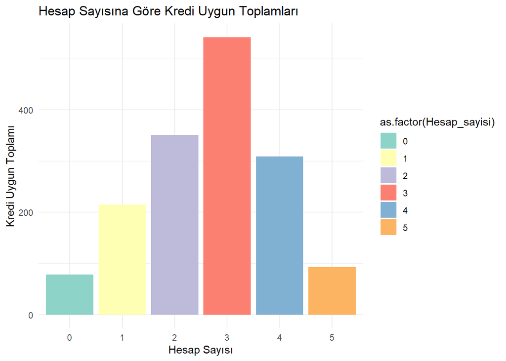

```r
# Hesap_sayisi'na göre gruplandırarak Kredi_uygun toplamını hesaplama
kredi_uygun_toplam <- birlestirilmis_veri %>%
  group_by(Hesap_sayisi) %>%
  summarise(Kredi_uygun_toplam = sum(Kredi_uygun))

# Grafiği oluşturma
ggplot(kredi_uygun_toplam, aes(x = as.factor(Hesap_sayisi), y = Kredi_uygun_toplam, fill = as.factor(Hesap_sayisi))) +
  geom_bar(stat = "identity") +
  labs(title = "Hesap Sayısına Göre Kredi Uygun Toplamları",
       x = "Hesap Sayısı",
       y = "Kredi Uygun Toplamı") +
  theme_minimal() +
  scale_fill_brewer(palette = "Set3")
```

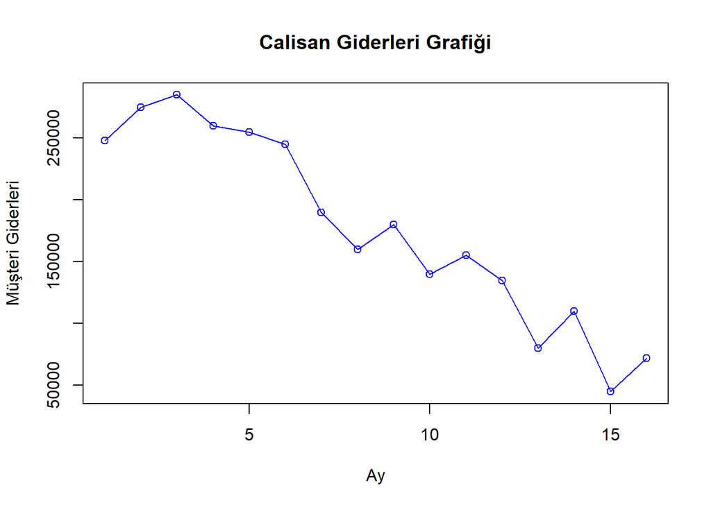

```r
birlestirilmis_veri$Islem_tarihi <- as.Date(birlestirilmis_veri$Islem_tarihi, format = "%d/%m/%y")


sorted_data <- birlestirilmis_veri[order(birlestirilmis_veri$Islem_tarihi), ]


tarih_yogunlugu <- sorted_data %>%
  group_by(Islem_tarihi) %>%
  summarise(yogunluk = n())

# Veri çerçevesini oluşturma
calisan_giderleri <- data.frame(
  giderler = c(248000, 275000, 285000, 260000, 255000, 245000, 190000, 160000, 180000, 140000, 155500, 135000, 80000, 110000, 45000, 72000)
)
plot(calisan_giderleri$giderler, type = "o", col = "blue",
     xlab = "Ay", ylab = "Müşteri Giderleri",
     main = "Calisan Giderleri Grafiği")
```

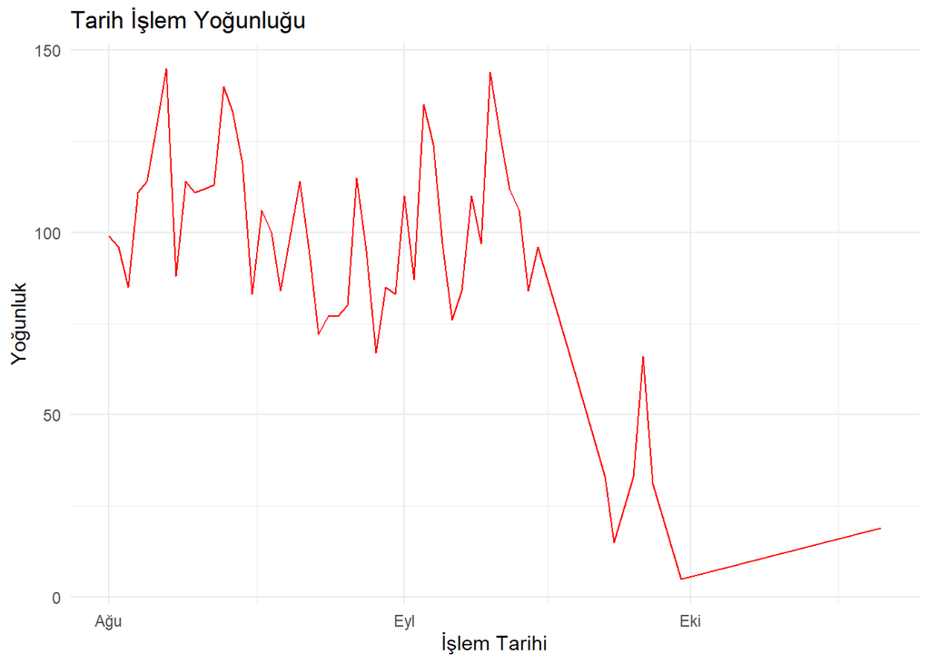

```r
musteri <- test_data$Musteri_Numarasi
isim <- test_data$Isim
soyisim <- test_data$Soyisim
kredi <- test_data$Kredi_uygun

son <- cbind(musteri,isim,soyisim,kredi)

data <- c(1:54)  # Örnek olarak 1'den 54'e kadar olan sayıları kullanıyoruz

# Tek sütunlu bir data frame oluşturuyoruz
df <- data.frame(column1 = data)

tarih <- cbind(tarih_yogunlugu,df)
write.csv(son, file = "son.csv", row.names = FALSE)
write.csv(tarih, file = "tarih.csv", row.names = FALSE)

ggplot(data = tarih_yogunlugu, aes(x = Islem_tarihi, y = yogunluk)) +
  geom_line(color = "red") +  # Çizgi grafiği çizimi, rengi mavi olarak belirledik
  labs(title = "Tarih İşlem Yoğunluğu",
       x = "İşlem Tarihi",
       y = "Yoğunluk") +  # Grafik için başlık ve eksen etiketlerini ekliyoruz
  theme_minimal()  # Temayı minimal yapıyoruz
```

**Projenin canlıya alınması**

*OvhCloud Sunucu Üzerinde SuiteCRM Kurulumu*

*Giriş*

Bu rapor, işletmemizde kullanılan Bilgi Yönetim Sistemi (BYS) kapsamında OverHead (ovhd) sunucu kiralayarak SuiteCRM’nin nasıl kurulduğunu detaylı bir şekilde anlatmaktadır. SuiteCRM, açık kaynaklı bir CRM yazılımıdır ve bu kurulum süreci, mevcut sistemlerimizi geliştirmek ve müşteri ilişkilerini daha etkin bir şekilde yönetmek için gerçekleştirilmiştir.

*1. Gereksinimler*

SuiteCRM kurulumuna başlamadan önce gerekli olan bileşenler ve araçlar şunlardır: • Ovhcloud hesabı • SSH erişimi • Docker kurulu bir web server • SuiteCRM kurulum dosyaları

*2. OvhCloud Sunucu Kiralama* 1. Hesap Oluşturma: OverHead web sitesine giderek bir hesap oluşturduk. 2. Sunucu Seçimi: İş gereksinimlerimize uygun bir sunucu planı seçtik. SuiteCRM’nin çalışması için önerilen sistem gereksinimlerine uygun bir plan belirledik. 3. Sunucu Kurulumu: Seçilen sunucuyu oluşturduk ve gerekli bilgileri aldık (IP adresi, kullanıcı adı, şifre).

*3 .Sunucuya SuiteCRM kurup Bağlantıları Sağlamak*

**Suite imagesini indirin**

docker pull bitnami/suitecrm:latest

**Bağlantı oluşturun**

docker network create suitecrm-network

**MariaDB kalıcılığı için bir hacim oluşturun ve bir MariaDB konteyneri oluşturun**

docker volume create –name mariadb_data docker run -d –name mariadb  
–env ALLOW_EMPTY_PASSWORD=yes  
–env MARIADB_USER=bn_suitecrm  
–env MARIADB_PASSWORD=bitnami  
–env MARIADB_DATABASE=bitnami_suitecrm  
–network suitecrm-network  
–volume mariadb_data:/bitnami/mariadb  
bitnami/mariadb:latest

**SuiteCRM kalıcılığı için hacimler oluşturun ve konteyneri başlatın**

docker volume create –name suitecrm_data docker run -d –name suitecrm  
-p 8080:8080 -p 8443:8443  
–env ALLOW_EMPTY_PASSWORD=yes  
–env SUITECRM_DATABASE_USER=bn_suitecrm  
–env SUITECRM_DATABASE_PASSWORD=bitnami  
–env SUITECRM_DATABASE_NAME=bitnami_suitecrm  
–network suitecrm-network  
–volume suitecrm_data:/bitnami/suitecrm  
bitnami/suitecrm:latest

**oluşturduğumuz web bağlantısı**

*http://162.19.249.190:8080/*